# BOT Flight Data Analysis

09/22/2023

## Name: Alexis Alexander

This experiment (concerptually) continues our class work on flight data.

We will continue to refer to (https://r4ds.hadley.nz/data-transform).

**However, we will expand and update our dataset by going to a root source – the Bureau of Transportation.

Go to the website https://www.transtats.bts.gov/DL_SelectFields.aspx?gnoyr_VQ=FIM&QO_fu146_anzr=Nv4%20Pn44vr45. This dataset allows access to information on domestic flight and domestic carriers, with monthly summary data.

# Packages

```r
library(nycflights13)
library(tidyverse)
library(janitor)
library(here)
```

# Get data from the online source.

Save the download to your data_raw directory. It will be a zipfile, but that will be OK. Don’t change the name on the zipfile.

## Load the BOT data

We take advantage of the here package to get the path to the file that we stored. We also may not that inside the zipfile is a csv file. We will read the csv file. We unpackage all of the data and organized them in a dataframe based on the year

```r
thisfile=here("data_raw", "DL_SelectFields_2017.zip")
df2017=read_csv(thisfile) %>% clean_names()
thisfile=here("data_raw", "DL_SelectFields_2018.zip")
df2018=read_csv(thisfile) %>% clean_names()
thisfile=here("data_raw", "DL_SelectFields_2019.zip")
df2019=read_csv(thisfile) %>% clean_names()
thisfile=here("data_raw", "DL_SelectFields_2020.zip")
df2020=read_csv(thisfile) %>% clean_names()
thisfile=here("data_raw", "DL_SelectFields_2021.zip")
df2021=read_csv(thisfile) %>% clean_names()
thisfile=here("data_raw", "DL_SelectFields_2022.zip")
df2022=read_csv(thisfile) %>% clean_names()
thisfile=here("data_raw", "DL_SelectFields_2023.zip")
df2023=read_csv(thisfile) %>% clean_names()
```

# Combine the Dataframes

Combining all of the rows into a single table from each data frame

```r
dfc=df2017 |>
  bind_rows(df2018) |>
  bind_rows(df2019) |>
  bind_rows(df2020) |>
  bind_rows(df2021) |>
  bind_rows(df2022) |>
  bind_rows(df2023)
```

### Create a new file

I will save this data as csv file with intent that future loading cna simply read this new file.

```r
write_csv(dfc,here("data","bot_flight_2017_2023m08.csv"))
```

# Create a Visualization

For Arrivals and Depatures from LGA

```r
dfcl=dfc |>
  filter(passengers>0, origin=="LGA" | dest =="LGA")
```

Creating a graph for the total passengers by month over a year

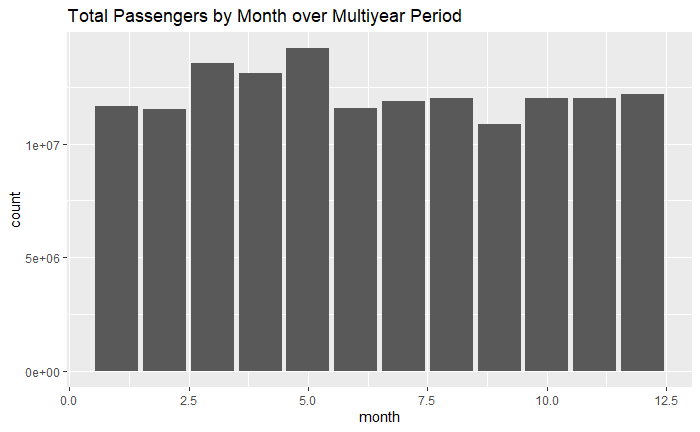

```r
dfcl|>
  ggplot(aes(month)) +
  geom_bar(aes(weight=passengers)) +
  ggtitle("Total Passengers by Month over Multiyear Period")
```

## Year over Year7

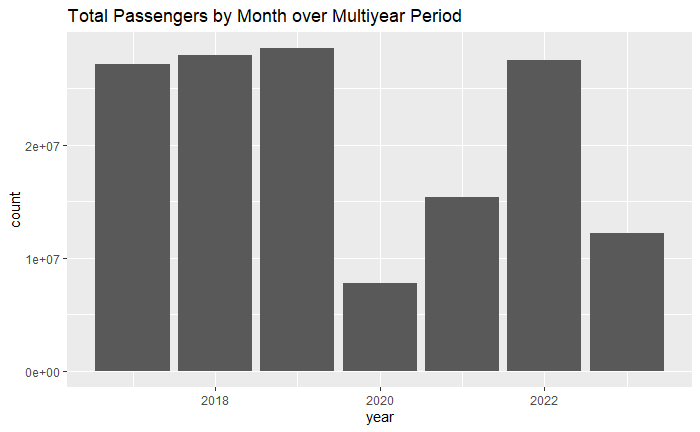

```r
dfcl|>
  ggplot(aes(year)) +
  geom_bar(aes(weight=passengers)) +
  ggtitle("Total Passengers by Month over Multiyear Period")
```